# GitTyee

Eric V

2023-07-08

# 1. What is this?

A high-level look at trends in catches of Tyee salmon in Campbell River’s legendary Tyee Pool. All data exploration is being completed for [fun](https://i.giphy.com/media/Cz6TlrRVVyv9S/giphy.webp) and to learn some new tools (namely [R Markdown](https://rmarkdown.rstudio.com/) and [plotly](https://plotly.com/r/)).

There are far more technical ways of examining this data, but they aren’t as much fun - and are frankly hard. This analysis is living and will evolve over time. All results and interpretation are purely speculative.

## 1.1 The data

This analysis uses the following publicly available data:

1. Annual catch records from the [Tyee Club](https://www.tyeeclub.org/catch-records/%3E).
2. Discharge data collected on the Campbell River by the [Water Survey of Canada](https://wateroffice.ec.gc.ca/index_e.html).
3. Annual Chinook Salmon escapement data available in the [DFO NuSEDS database](https://open.canada.ca/data/en/dataset/c48669a3-045b-400d-b730-48aafe8c5ee6).
4. Annual catch statistics from the [North Pacific Anadromous Fish Commission](https://npafc.org/statistics/)
5. Area based commercial catch statistics from DFO are [available from 2001 to 2016](https://www.pac.dfo-mpo.gc.ca/stats/smon/index-eng.html)

This is certainly an interesting dataset, but it has its limitations. For example, there is no information on effort (# boats per day) and biological data is limited (e.g. size, girth and age of tyees or number of undersized fish captured).

# 2. Chinook Salmon

## 2.1 What we know about Chinook Salmon in the Campbell River

There has been a lot of information collected on Campbell River Chinook Salmon, including Tyee Salmon captured in the Tyee Pool, however, most of this data is not readily available. Data that is available (and that I have found) is summarized below.

**1) Spawn Timing**

- Bi-weekly spawner and redd surveys of the Campbell River canyon, where most Chinook Salmon spawn, have been completed since 2014 (e.g. Thornton et al. 2022). These data show that Chinook spawning occurs from late September through early November and peaks in mid-October and that spawners reside in the river for ~12 days.

**2) Age Class Structure**

**3) Size-at-Age**

**4) Fecundity**

- [Ewart & Anderson, 2013](http://www.crsalmonfoundation.ca/wp-content/uploads/2021/01/CRSF12BYchinreportfinal.pdf) report that female Chinook in the Campbell River in 2012 carried roughly ~5,700, a decrease from the roughly 6,000 eggs typically carried.

**5) Juvenile Life History**

- Juvenile Chinook Salmon in the Campbell River have been studied intensively since 2015 (e.g. [Thornton et al. 2022](https://www.bchydro.com/content/dam/BCHydro/customer-portal/documents/corporate/environment-sustainability/water-use-planning/vancouver-island/jhtmon-15-Yr-7-2022-07-25.pdf). These data suggests fry emerge in February-March and that nearly all Campbell River Chinook out migrate as Age-0+ juveniles from March through July. Smaller recently emerged Age-0+ fry are dominant and typically captured from March through early May (37 to 52 m). Larger Age-0+ smolts are less common and move out from May through July (64 to 88 mm).

**6) Estimated Juvenile Production**

- Estimates of juvenile Chinook production based on numbers of observed spawners have generally been less than numbers trapped throughout the outmigration period ([Thornton et al. 2022](https://www.bchydro.com/content/dam/BCHydro/customer-portal/documents/corporate/environment-sustainability/water-use-planning/vancouver-island/jhtmon-15-Yr-7-2022-07-25.pdf), which may be due to increased juvenile survival or inaccurate/coarse estimates of fecundity.

**7) Estimates of Marine Survival**

- Marine survival of unfed fry released from the Quinsam hatchery range from 0.2% to 0.4% (yes, that is 0.002 to 0.004) ([Ewart & Anderson 2013](http://www.crsalmonfoundation.ca/wp-content/uploads/2021/01/CRSF12BYchinreportfinal.pdf)).

**8) Hatchery Influence and Population Status**

- [Ewart & Anderson 2013](http://www.crsalmonfoundation.ca/wp-content/uploads/2021/01/CRSF12BYchinreportfinal.pdf) report that 56% of the otoliths examined from the 2012 return showed no signs of hatchery marking and are assumed wild. The remaining 44% are presumed to have originated from instream incubators (31%), seapen released smolts (4%) and Quinsam River released smolts (9%).

Table 1. Size at age of Chinook Salmon captured in Campbell River watershed from [Sturham et al. 1999](https://publications.gc.ca/collections/collection_2014/mpo-dfo/Fs97-4-2477-eng.pdf)

| Waterbody | Age | n | % of Total | Size Range (mm) | Mean Lenght (mm) |
| --- | --- | --- | --- | --- | --- |
| Campbell River | 3 | 6 | 7.9 | 500 - 699 | 595.0 |
| Campbell River | 4 | 34 | 44.7 | 550 - 949 | 779.5 |
| Campbell River | 5 | 35 | 46.1 | 700 - 949 | 842.5 |
| Campbell River | 6 | 1 | 1.3 | 900 - 949 | 930.0 |
| Quinsam Hatchery | 3 | 76 | 20.2 | 400 - 749 | 619.5 |
| Quinsam Hatchery | 4 | 225 | 59.8 | 550 - 899 | 743.5 |
| Quinsam Hatchery | 5 | 73 | 19.4 | 700 - 949 | 834.0 |
| Quinsam Hatchery | 6 | 2 | 0.5 | 750 - 849 | 784.0 |
| Quinsam River | 3 | 46 | 22.8 | 500 - 849 | 663.0 |
| Quinsam River | 4 | 114 | 56.4 | 550 - 949 | 733.5 |
| Quinsam River | 5 | 40 | 19.8 | 700 - 949 | 818.0 |
| Quinsam River | 6 | 2 | 1.0 | 800 - 849 | 838.0 |

## 2.2 What else do we know about Chinook Salmon?

**1) They are decreasing in size**

[output not shown]

# 3. Let’s look at the Tyee catch data!

So, let’s begin by having a look at the catch data from the Tyee pool and how catches fluctuate relative to Chinook Salmon escapement in the Campbell River.

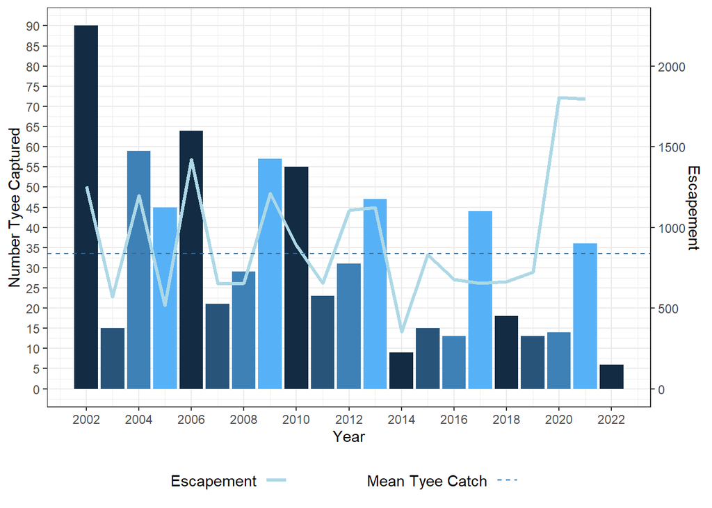

Figure 1: Trends in Tyee Salmon captures and Campbell River Chinook Salmon escapement.

## 3.1. What could be affecting returns and catches?

At it’s most basic level, there are four things that are likely affecting catches of Tyee salmon (in reality, there are many many many many many more.

**3.1.1. Juvenile recruitment**

- This is determined by the number of eggs that are deposited (for easy math, lets say females account for 50% of escapement, that each one deposits 4000 eggs and that egg to fry survival is 10%). We will assume that fish that survive to fry will enter the sea. Hydrometric data on the Campbell is vailable back to 1949 and it is likely that extreme high or low flow events (e.g. greater than 300 cms, less than ??50 cms??) during the rearing/incubation period (maybe October to February) will reduce juvenile recruitment.

**3.1.2. Marine survival and productivity**

- This is way too complicated for right now. Let’s feel warm and fuzzy by assuming survival and productivity are stable (side note, they arent!). But if we don’t do this we can’t assume that proportions calculated from Sturham et al. are representative of current returns (they likely are not, fish sizes are decreasing as water temperatures and pH increase, so there are likely fewer Tyee returning now than in previous years).

**3.1.3. Fishing effort and catchability**

- For now, I am going to assume effort (# of boats fishing per tide/day) is constant and that catchability (percent of Tyees present that are captured) are stable. In reality, effort has likely decreased over time (especially since 2014) and catchability has likely increased as peoples knowledge, skill and fishing technology have improved over time (not everyone though, I still suck). Either way, not much I am going to do with this.

**3.1.4. Fishing Conditions** * No question that fewer fish will be captured during seasons with poor fishing conditions (e.g. very windy, lots of rain). It is also possible that fish behaviour will change in response to river conditions. Certainly there was a lot of speculation that low catches in 2022 were due to high water levels (as evidenced by lowest catch on record while many very large fish were being captured in the river).

# 4. So, what can we look at?

Well, we could look at everything, but we won’t do that because I am lazy. According to my pea brain, there are two ways we can approach this:

1.) We can look at what factors influenced how many fish were available for capture in the Tyee pool (i.e. how historic conditions may have contributed to observed captures), and/or; 2.) We can look at what factors influenced how returning fish were captured (i.e. conditions during the fishing season)

## 4.1 How Historic Conditions Influenced Captures

We can *VERY CRUDELY* estimate the number of Tyee salmon that should return to the Campbell River if we make a couple of big assumptions:

- Fecundity is ~5,700 eggs per female ([Ewart & Anderson, 2013](http://www.crsalmonfoundation.ca/wp-content/uploads/2021/01/CRSF12BYchinreportfinal.pdf)
- Sex ratios are 60:40 female to male ([Sturham et al. 1999](https://publications.gc.ca/collections/collection_2014/mpo-dfo/Fs97-4-2477-eng.pdf). on Sturham data for Campbell River)
- Egg to fry survival is approximately 0.003 (estimated from Thronton et al. 2022).
- Tyee Salmon are over 900 mm. In the Campbell River, I will assume that 10% of Age-4 male adults, 15% of Age-5 spawners (both sexes), and all Age-6 fish are >900 mm and therefore >30 lbs (this is **very** loosely based on Sturham data, but I have not seen raw tables so its an guestimate).

But this doesn’t make sense, if each female produced 17.1 offspring escapement would be increasing rapidly. And it most certainly is not. So, what gives?

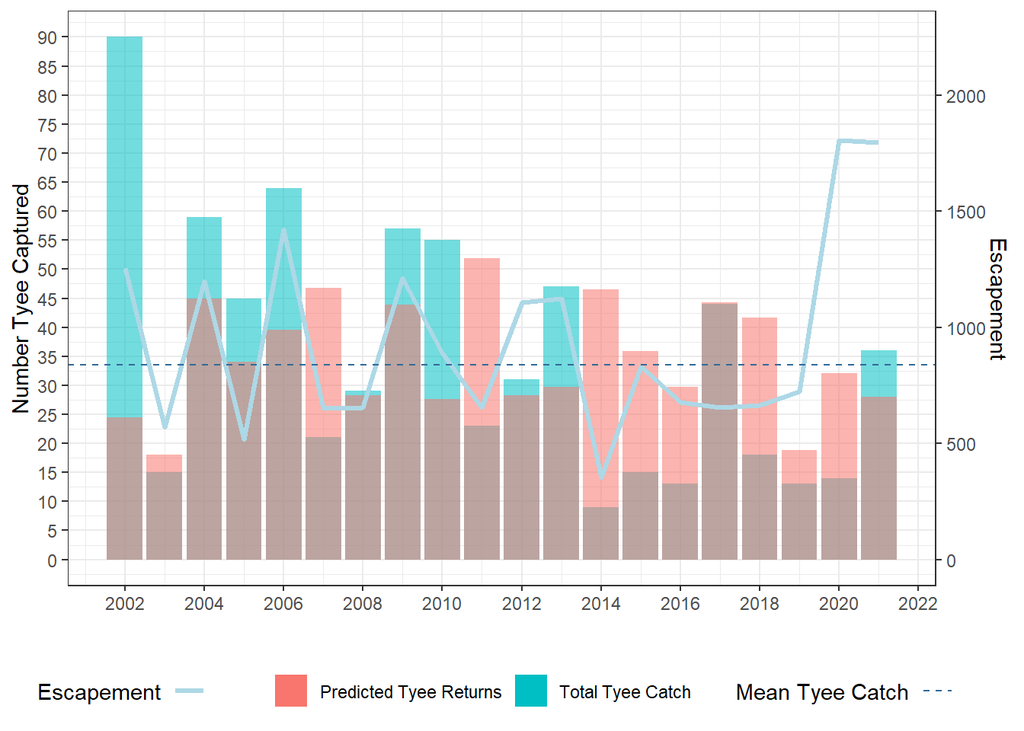

Figure 2: Comparison of catches of Tyee Salmon, predicted returns of Tyee Salmon and annual Chinook Salmon escapement counts.

Well this is interesting!

1. There is a fairly drastic shift in predicted returns that coincides with the crash in 2014. Prior to the crash, predicted returns are consistently underestimated (73% of years are less than actual catches) whereas after the crash predicted Tyee returns are greater than total tyee catches in all but one year.

A couple of things to keep in mind when trying to understand what this means.

- We should assume that only a proportion of all returning Tyees are captured each year. If all Tyee salmon were captured each year, we would be actively selecting against large fish and it would be reasonable to expect to see a continuous decline in the total number of Tyees returning each year. So, based on this logic (and my personal observation of tyees on the spawning ground), the predicted Tyee returns should always be greater than total catches.
- The formula and values used to estimate predicted returns of tyee salmon do not change. If we assume there is no change in catchability and that the number of Tyees captured in the pool is a representation of the number of tyees that return to the river there appears to have been a dramatic reduction in the number of Tyee salmon in 2014. This aligns with escapement data, which is also greatly reduced.
- Additionally, the figure shows that my formula and estimates are way off - which is not surprising as they were very crude! This is most apparent in the years prior to the 2014 crash, but suggests predictions after the crash are also off too.

So, what happened in 2014!? Did runs crash everywhere? Let’s have a look at escapement in other systems in the area.

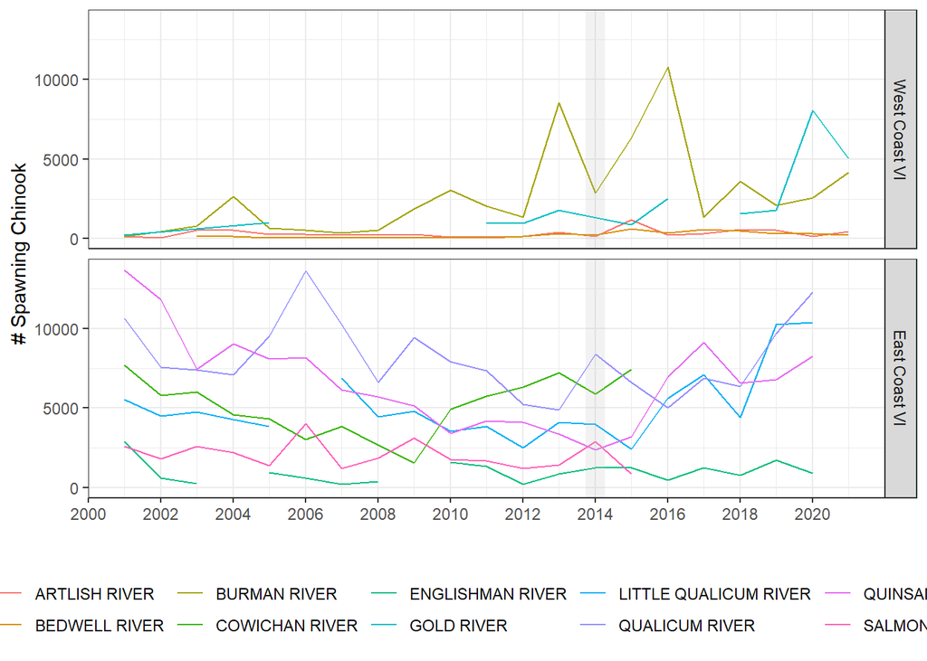

Figure 3: Chinook Salmon escapement from rivers on East and West Coast of Vancouver Island.

### MAYBE RERUN ESCAPEMENT PLOT USING ALL ESCPAEMENT DATA!? FACET BY AREA?

### ADD METRIC THAT STANDARDIZES ESCAPEMENT. E.G. total annual returns vs mean annual returns.

## Influence of river flow on catches

Last year there was a lot of speculation that high flows in the Campbell River may have caused fish to move directly into the river rather than staging in the pool. Let’s look at flow in the Campbell River to see how 2022 flows compared to previous years.

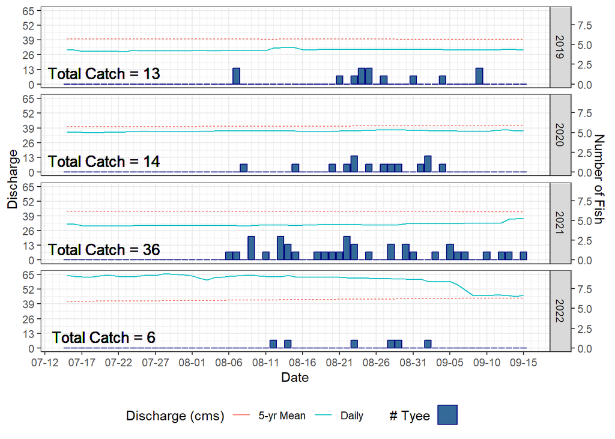

Well, it’s clear that flows in 2022 were higher than past years and higher than mean flows over the past 5-years. But this doesn’t mean that is why fewer fish were captured. Either way let’s take a closer look at the correlation between flow and capture.

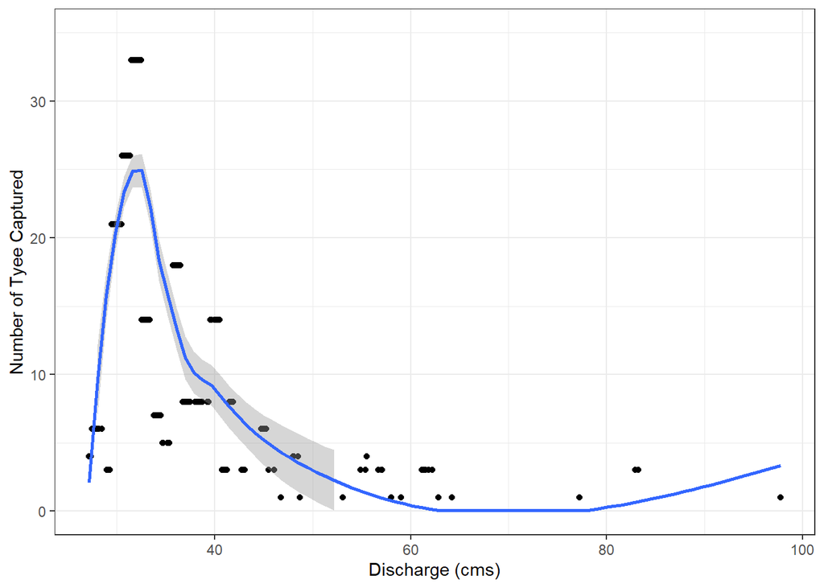

Figure 5: Relationship between river flow and fish capture

OK, well there is a relationship (that could be due to a number of things). Lets have a look at some of the older data.

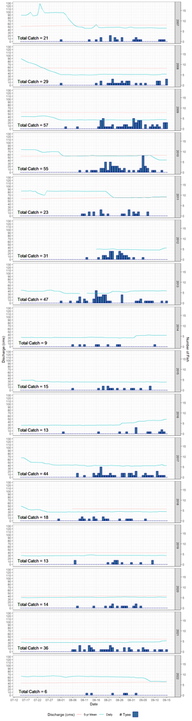

Figure 6: Catches of Tyee Salmon since 2007 relative to flow in the Campebll River.

Let’s look at commercial catches. Maybe there is a fishery that could be intercepting a large number of Tyees.

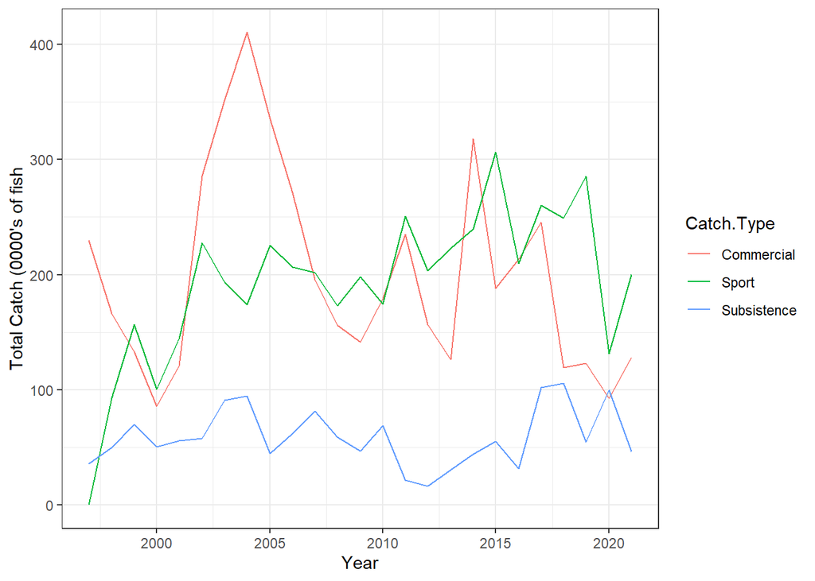

```r
can.catch <- comm.catch %>% rename(Catch.Type = 'Catch Type',
                                   Data.Type  = 'Data Type') %>%
                            mutate(Area         = as.factor(Area),
                                   Species      = as.factor(Species),
                                   Year         = as.numeric(Year),
                                   Catch.Type = as.factor(Catch.Type)) %>%
                            filter(Country   ==  "Canada",
                                   Year      >= 1997,
                                   Data.Type == "Number (000's)")

can.catch.cn <- can.catch %>% filter(Species   == "Chinook",
                                     Area      == "Whole country")

      CN.catch.plot <- ggplot(can.catch.cn) +
                              geom_line(aes(x = Year, y = Total.Catch, color = Catch.Type)) +
                       labs(x = "Year", y = "Total Catch (0000's of fish") +
                       theme_bw()

      CN.catch.plot
```

```r
can.catch.cn2 <- can.catch %>% filter(Species   == "Chinook",
                                      Catch.Type == "Sport")
      summary(can.catch.cn2)
```

```
##    Country          Whole Country/Province/State
##  Length:125         Length:125
##  Class :character   Class :character
##  Mode  :character   Mode  :character
##
##
##
##
##                           Area       Species          Catch.Type
##  Haida Gwaii                :25   Chinook:125   Commercial :  0
##  North Coast                :25   Cherry :  0   Sport      :125
##  South Coast                :25   Chum   :  0   Subsistence:  0
##  West Coast Vancouver Island:25   Coho   :  0
##  Whole country              :25   Pink   :  0
##  Amur River Basin           : 0   Sockeye:  0
##  (Other)                    : 0   (Other):  0
##   Data.Type              Year       Total.Catch
##  Length:125         Min.   :1997   Min.   :  0.00
##  Class :character   1st Qu.:2003   1st Qu.: 25.80
##  Mode  :character   Median :2009   Median : 54.00
##                     Mean   :2009   Mean   : 77.34
##                     3rd Qu.:2015   3rd Qu.: 92.49
##                     Max.   :2021   Max.   :306.68
##
```

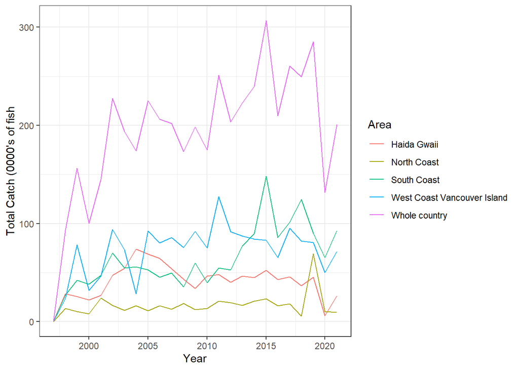

```r
      CN.catch.plot2 <- ggplot(can.catch.cn2) +
                              geom_line(aes(x = Year, y = Total.Catch, color = Area)) +
                                   labs(x = "Year", y = "Total Catch (0000's of fish") +
                                   theme_bw()
      CN.catch.plot2
```

```r
can.catch.sk <- can.catch %>% filter(Species   == "Sockeye")

colnames
```

[output not shown]

```r
summary(can.catch.cn2)
```

```
##    Country          Whole Country/Province/State
##  Length:125         Length:125
##  Class :character   Class :character
##  Mode  :character   Mode  :character
##
##
##
##
##                           Area       Species          Catch.Type
##  Haida Gwaii                :25   Chinook:125   Commercial :  0
##  North Coast                :25   Cherry :  0   Sport      :125
##  South Coast                :25   Chum   :  0   Subsistence:  0
##  West Coast Vancouver Island:25   Coho   :  0
##  Whole country              :25   Pink   :  0
##  Amur River Basin           : 0   Sockeye:  0
##  (Other)                    : 0   (Other):  0
##   Data.Type              Year       Total.Catch
##  Length:125         Min.   :1997   Min.   :  0.00
##  Class :character   1st Qu.:2003   1st Qu.: 25.80
##  Mode  :character   Median :2009   Median : 54.00
##                     Mean   :2009   Mean   : 77.34
##                     3rd Qu.:2015   3rd Qu.: 92.49
##                     Max.   :2021   Max.   :306.68
##
```

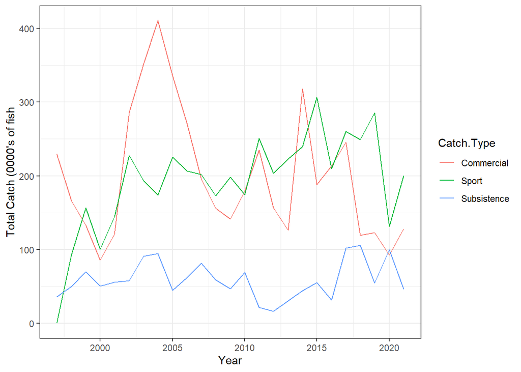

```r
CN.catch.plot
```

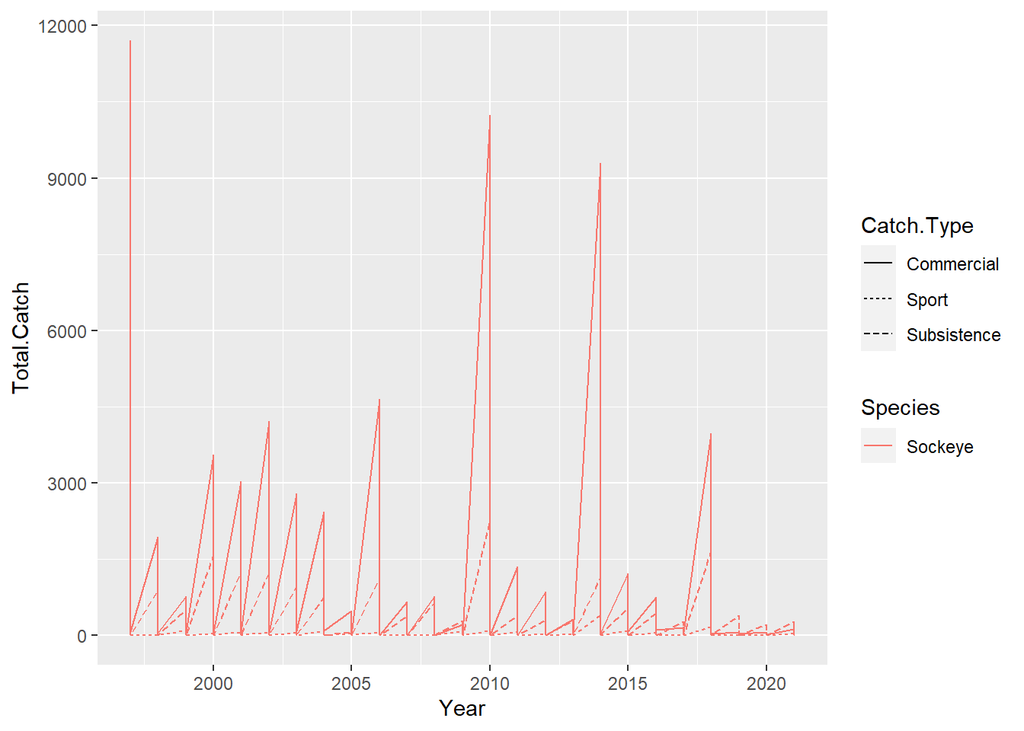

```r
sk.catch.plot <- ggplot(can.catch.sk) +
                        geom_line(aes(x = Year, y = Total.Catch, color = Species, linetype = Catch.Type))
sk.catch.plot
```

###Notes Plot peak flows 4 to 5 years previous (e.g. impact of peak flows on recruitment). - Assume mortality at >200 cms - spawning habitat lost at 300-400 cms - Is Quinsam flow regulated? Ask Mary.

Is return age genetic? Or environmental?

### Supplemental Tables and Figures

Table 1. Size at age of male and female Chinook Salmon captured in Campbell River watershed

| Waterbody | Sex | Age | n | % of Total (by Sex) | % of Total (by Stream) | Size Range (mm) | Mean Lenght (mm) | Std. Error |
| --- | --- | --- | --- | --- | --- | --- | --- | --- |
| Campbell River | F | 3 | 0 | 0.00 | 0.00 | 500 - 699 | 595 | 20.82 |
| Campbell River | M | 3 | 6 | 0.19 | 0.08 | 500 - 699 | 595 | 20.82 |
| Campbell River | F | 4 | 21 | 0.48 | 0.28 | 700 - 899 | 783 | 10.69 |
| Campbell River | M | 4 | 13 | 0.41 | 0.17 | 550 - 949 | 776 | 23.30 |
| Campbell River | F | 5 | 23 | 0.52 | 0.30 | 750 - 949 | 839 | 7.51 |
| Campbell River | M | 5 | 12 | 0.38 | 0.16 | 700 - 949 | 846 | 14.43 |
| Campbell River | F | 6 | 0 | 0.00 | 0.00 | 900 - 949 | 930 | 0.00 |
| Campbell River | M | 6 | 1 | 0.03 | 0.01 | 900 - 949 | 930 | 0.00 |
| Quinsam Hatchery | F | 3 | 9 | 0.04 | 0.02 | 550 - 749 | 644 | 15.33 |
| Quinsam Hatchery | M | 3 | 67 | 0.38 | 0.18 | 400 - 749 | 595 | 6.84 |
| Quinsam Hatchery | F | 4 | 130 | 0.65 | 0.35 | 600 - 899 | 742 | 3.77 |
| Quinsam Hatchery | M | 4 | 95 | 0.54 | 0.25 | 550 - 899 | 745 | 5.64 |
| Quinsam Hatchery | F | 5 | 61 | 0.30 | 0.16 | 700 - 949 | 823 | 5.76 |
| Quinsam Hatchery | M | 5 | 12 | 0.07 | 0.03 | 750 - 949 | 845 | 13.57 |
| Quinsam Hatchery | F | 6 | 1 | 0.00 | 0.00 | 800 - 849 | 812 | 0.00 |
| Quinsam Hatchery | M | 6 | 1 | 0.01 | 0.00 | 750 - 799 | 756 | 0.00 |
| Quinsam River | F | 3 | 1 | 0.01 | 0.00 | 700 - 749 | 700 | 0.00 |
| Quinsam River | M | 3 | 45 | 0.41 | 0.22 | 500 - 849 | 626 | 12.07 |
| Quinsam River | F | 4 | 58 | 0.63 | 0.29 | 650 - 849 | 744 | 4.73 |
| Quinsam River | M | 4 | 56 | 0.51 | 0.28 | 550 - 949 | 723 | 9.35 |
| Quinsam River | F | 5 | 31 | 0.34 | 0.15 | 700 - 949 | 830 | 7.54 |
| Quinsam River | M | 5 | 9 | 0.08 | 0.04 | 700 - 949 | 806 | 21.00 |
| Quinsam River | F | 6 | 2 | 0.02 | 0.01 | 800 - 849 | 838 | 2.83 |
| Quinsam River | M | 6 | 0 | 0.00 | 0.00 | 800 - 849 | 838 | 2.83 |